# Introduction à la modélisation statistique bayésienne

Ladislas Nalborczyk & Thierry Phénix

### Planning

## Cours

Cours 1: Introduction à l'inférence bayésienne

Cours 2: Modèle beta-binomial

**Cours 3 & 4: Modèle de régression linéaire**

Cours 5: Markov Chain Monte Carlo

Cours 6: Modèle linéaire généralisé

Cours 7: Comparaison de modèles

Cours 8: Modèles multi-niveaux

Cours 9: Introduction à `brms`

Cours 10: Data Hackaton

## Plan

- **Rappels et objectifs**
- Régression linéaire : multiples facteurs continus
- Régression linéaire : un facteur catégoriel
- Régression linéaire : 2 facteurs catégoriels et interaction

### Rappels

### WAFFLE DATA

```r
# L'ordre est important pour utiliser la fonction map de rethinking...
library(tidyverse)
library(rethinking)
data(WaffleDivorce)
df1 <- WaffleDivorce

kable(df1[1:10, 1:9], caption = "Données sur la population américaine par état")
```

| Location | Loc | Population | MedianAgeMarriage | Marriage | Marriage.SE | Divorce | Divorce.SE | WaffleHouses |
| --- | --- | --- | --- | --- | --- | --- | --- | --- |
| Alabama | AL | 4.78 | 25.3 | 20.2 | 1.27 | 12.7 | 0.79 | 128 |
| Alaska | AK | 0.71 | 25.2 | 26.0 | 2.93 | 12.5 | 2.05 | 0 |
| Arizona | AZ | 6.33 | 25.8 | 20.3 | 0.98 | 10.8 | 0.74 | 18 |
| Arkansas | AR | 2.92 | 24.3 | 26.4 | 1.70 | 13.5 | 1.22 | 41 |
| California | CA | 37.25 | 26.8 | 19.1 | 0.39 | 8.0 | 0.24 | 0 |
| Colorado | CO | 5.03 | 25.7 | 23.5 | 1.24 | 11.6 | 0.94 | 11 |
| Connecticut | CT | 3.57 | 27.6 | 17.1 | 1.06 | 6.7 | 0.77 | 0 |
| Delaware | DE | 0.90 | 26.6 | 23.1 | 2.89 | 8.9 | 1.39 | 3 |
| District of Columbia | DC | 0.60 | 29.7 | 17.7 | 2.53 | 6.3 | 1.89 | 0 |
| Florida | FL | 18.80 | 26.4 | 17.0 | 0.58 | 8.5 | 0.32 | 133 |

### Rappels

### DIVORCE ~ MARIAGE

On observe un lien positif entre le taux de mariage et le taux de divorce, mais est-ce que cela a vraiment un sens ?

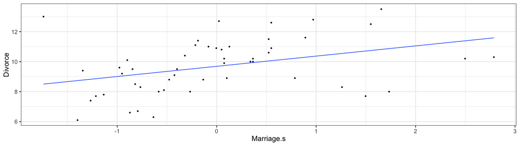

```r
df1$Marriage.s <-
    (df1$Marriage - mean(df1$Marriage) ) / sd(df1$Marriage)

ggplot(df1, aes(x = Marriage.s, y = Divorce) ) +
geom_point(size = 2) +
geom_smooth(method = "lm", se = FALSE) +
theme_bw(base_size = 25)
```

### Rappels

### DIVORCE ~ AGE MEDIAN DE MARIAGE

On observe l'association inverse entre le taux de divorce et l'âge médian de mariage…

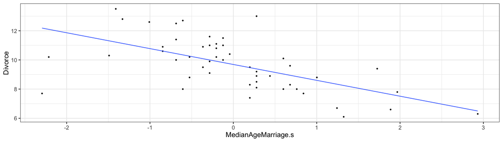

```r
df1$MedianAgeMarriage.s <-
        (df1$MedianAgeMarriage - mean(df1$MedianAgeMarriage) ) / sd(df1$MedianAgeMarriage)

ggplot(df1, aes(x = MedianAgeMarriage.s, y = Divorce) ) +
geom_point(size = 2) +
geom_smooth(method = "lm", se = FALSE) +
theme_bw(base_size = 25)
```

### Rappels

### MODÈLE - En pratique

Taux de divorce en fonction du taux de mariage

Implémentation du modèle

```r
mod1 <- map(alist(
        Divorce ~ dnorm(mu, sigma),
        mu <- a + bA * Marriage.s,
        a ~ dnorm(10, 10),
        bA ~ dnorm(0 , 1),
        sigma ~ dunif(0, 10) ),
        data = df1)
```

Estimation des paramètres

```r
precis(mod1, prob = 0.95, corr = TRUE)
```

```
      mean   sd 2.5% 97.5%
a     9.69 0.24 9.22 10.15
bA    0.64 0.23 0.19  1.10
sigma 1.67 0.17 1.34  2.00
```

### Rappels

### MODÈLE - En pratique

Taux de divorce en fonction de l'age médian de mariage

Implémentation du modèle

```r
mod2 <- map(alist(
        Divorce ~ dnorm(mu, sigma),
        mu <- a + bA * MedianAgeMarriage.s,
        a ~ dnorm(10, 10),
        bA ~ dnorm(0 , 1),
        sigma ~ dunif(0, 10) ),
        data = df1)
```

Estimation des paramètres

```r
precis(mod2, prob = 0.95, corr = TRUE)
```

```
       mean   sd  2.5% 97.5%
a      9.69 0.20  9.29 10.09
bA    -1.04 0.20 -1.44 -0.65
sigma  1.45 0.14  1.16  1.73
```

> - Lequel de ces deux prédicteurs est le meilleur ?
> - Ces deux prédicteurs ne sont-ils pas redondants ?

## Cours

Cours 1: Introduction à l'inférence bayésienne

Cours 2: Modèle beta-binomial

**Cours 3 & 4: Modèle de régression linéaire**

Cours 5: Markov Chain Monte Carlo

Cours 6: Modèle linéaire généralisé

Cours 7: Comparaison de modèles

Cours 8: Modèles multi-niveaux

Cours 9: Introduction à `brms`

Cours 10: Data Hackaton

## Plan

- Rappels et objectifs
- **Régression linéaire : multiples facteurs continus**
- Régression linéaire : un facteur catégoriel
- Régression linéaire : 2 facteurs catégoriels et interaction

### MODÈLE - Théorique

> Quelle est la valeur prédictive d'une variable, une fois que je connais tous les autres prédicteurs ?

\[ \begin{align*} &\color{orangered}{D_{i} \sim \mathrm{Normal}(\mu_{i},\sigma)} \\ &\mu_{i}= \alpha + \beta_{R}R_{i} + \beta_{A}A_{i} \\ &\color{steelblue}{\alpha \sim \mathrm{Normal}(10,10)} \\ &\color{steelblue}{\beta_{R} \sim \mathrm{Normal}(0,1)} \\ &\color{steelblue}{\beta_{A} \sim \mathrm{Normal}(0,1)}\\ &\color{steelblue}{\sigma \sim \mathrm{Uniform}(0,10)} \end{align*} \]

Ce modèle répond à deux questions :

- Une fois connue le taux de mariage, quelle valeur ajoutée apporte la connaissance de l'âge médian du mariage ?
- Une fois connue l'âge médian du mariage, quelle valeur ajoutée apporte la connaissance de le taux de mariage ?

### Régression multiple

### MODÈLE - En pratique

Implémentation du modèle

```r
mod3 <- map(alist(
        Divorce ~ dnorm(mu, sigma),
        mu <- a + bR*Marriage.s + bA*MedianAgeMarriage.s,
        a ~ dnorm(10, 10),
        bR ~ dnorm(0, 1),
        bA ~ dnorm(0, 1),
        sigma ~ dunif(0 ,10) ),
        data = df1)
```

Estimation des paramètres

```r
precis(mod3)
```

```
       mean   sd  5.5% 94.5%
a      9.69 0.20  9.36 10.01
bR    -0.13 0.28 -0.58  0.31
bA    -1.13 0.28 -1.58 -0.69
sigma  1.44 0.14  1.21  1.67
```

> Interprétation:  
> une fois qu'on connait l'âge median de mariage dans un état, connaître le taux de mariage de cet état n'apporte pas vraiment d'information (i.e., de puissance de prédiction) supplémentaire…

### Régression multiple

### VISUALISER : les prédictions du modèle

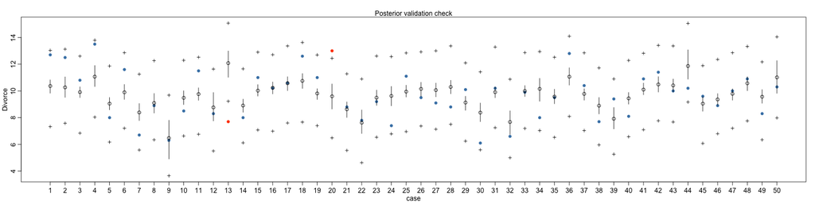

```r
source("postcheck2.R")
postcheck2(mod3, window = nrow(df1) )
```

En plus d'essayer de comprendre les coefficients estimés, il est important d'évaluer les prédictions du modèle, i.e. comparer aux données observées.  
Cela nous permet de répondre à deux questions:

- est-ce que le modèle *fit* bien les données ?
- où est-ce que le modèle échoue ?

### Régression multiple

### VISUALISER : les prédictions vs les observations

```r
# call link without specifying new data so it uses original data
mu <- link(mod3, refresh = 0)

# summarize samples across cases
mu.mean <- apply(mu, 2, mean)
mu.HPDI <- apply(mu, 2, HPDI, prob = 0.95)

# simulate observations
divorce.sim <- sim(mod3, n = 1e4, refresh = 0)
divorce.HPDI <- apply(divorce.sim, 2, HPDI, prob = 0.95)
```

```r
p <- ggplot(data = df1, aes(x = Divorce, y = mu.mean) ) + xlab(label = "Divorce observé") + ylab(label = "Divorce prédit") +
    geom_point(size = 5, pch = 1, col = "steelblue") +
    geom_abline(intercept = 0, slope = 1, lty = 2) +
    theme_bw(base_size = 25)

for (i in 1:nrow(df1) ){
    dfplot <- data.frame(xi = df1$Divorce[i], y1 = mu.HPDI[1,i], y2 = mu.HPDI[2,i])
    p <- p + geom_segment(inherit.aes = FALSE, aes(x = xi, xend = xi, y = y1, yend = y2), col = "steelblue", data = dfplot)
}
```

### Régression multiple

### VISUALISER : les prédictions vs les observations

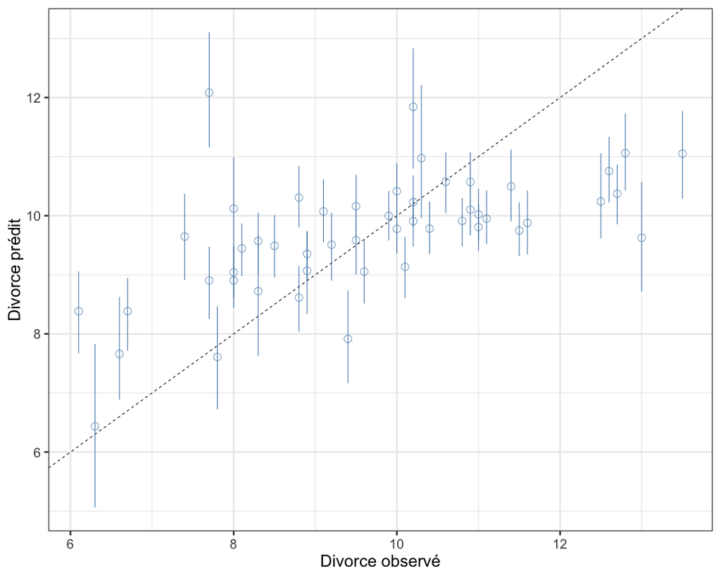

### Régression multiple

### VISUALISER : la distribution des résidus

```r
# compute residuals
divorce.resid <- d$Divorce - mu.mean

# get ordering by divorce rate
o <- order(divorce.resid)

# make the plot
dotchart(divorce.resid[o], labels = d$Loc[o], xlim = c(-6, 5) )
abline(v = 0, col = col.alpha("black", 0.2) )

for (i in 1:nrow(d) ){
    j <- o[i] # which State in order
    lines(d$Divorce[j] - c(mu.HPDI[1,j], mu.HPDI[2,j]), rep(i,2) )
    points(d$Divorce[j] - c(divorce.HPDI[1,j], divorce.HPDI[2,j]),
            rep(i,2), pch = 3, cex = 0.6, col = "gray")
}
```

### Visualiser les prédictions du modèle

### VISUALISER : la distribution des résidus

Négatif: moins de divorces que prédit, positif: plus de divorces que prédit.

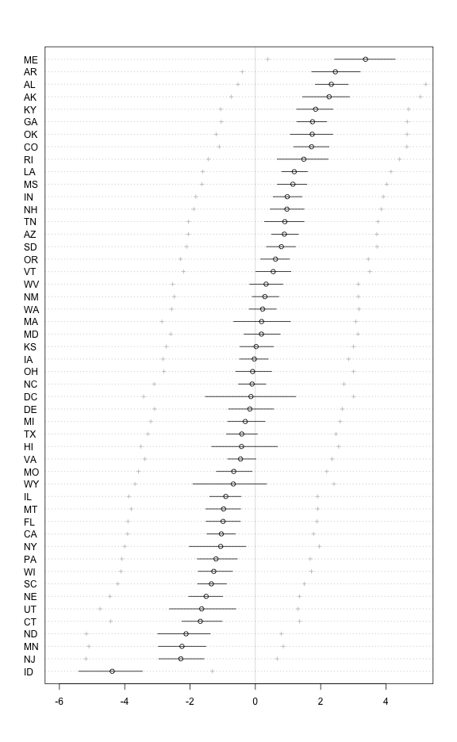

### Régression multiple

### LES RISQUES

> Pourquoi ne pas simplement construire un modèle incluant **TOUS** les prédicteurs et “regarder ce qu'il se passe” ?
- Raison 1: *multicollinearité des prédicteurs*
- Raison 2: *dépendance entre les prédicteurs*
- Raison 3: *overfitting* (cf. cours 7)

### Régression multiple

### LES RISQUES : La colinéarité

Situation dans laquelle certains prédicteurs sont très fortement corrêlés. Par exemple, essayons de prédire la taille d'un individu par la taille de ses jambes.

```r
N <- 100
height <- rnorm(N, 179, 2)
leg_prop <- runif(N, 0.4, 0.5)
leg_left <- leg_prop * height + rnorm(N, 0, .5)
leg_right <- leg_prop * height + rnorm(N, 0, .5)
df2 <- data.frame(height, leg_left, leg_right)
```

| height | leg_left | leg_right |
| --- | --- | --- |
| 176.4157 | 72.40306 | 72.90031 |
| 181.7817 | 83.47710 | 82.62449 |
| 181.3773 | 84.62899 | 84.27898 |
| 179.4207 | 88.25875 | 88.22445 |
| 177.5582 | 87.61438 | 88.70942 |
| 179.8288 | 74.09668 | 74.46373 |
| 180.2511 | 76.50357 | 76.94513 |
| 180.5677 | 86.42285 | 86.37345 |
| 177.0021 | 79.29269 | 78.66673 |
| 178.8048 | 82.45690 | 83.06226 |

### Régression multiple

### LES RISQUES : La colinéarité

Implémentation du modèle

```r
mod5 <- map(alist(
        height ~ dnorm(mu, sigma),
        mu <- a + bl * leg_left + br * leg_right,
        a ~ dnorm(0, 100),
        bl ~ dnorm(0, 10),
        br ~ dnorm(0, 10),
        sigma ~ dunif(0, 10) ),
        data = df2,
        start = list(a = mean(df2$height), sigma = sd(df2$height) ) )
```

Estimation des paramètres

```r
precis(mod5, prob = 0.95)
```

```
        mean   sd   2.5%  97.5%
a     178.50 3.09 172.44 184.57
sigma   1.98 0.14   1.71   2.25
bl      0.37 0.25  -0.12   0.86
br     -0.36 0.25  -0.85   0.13
```

### Régression multiple

### LES RISQUES : La colinéarité

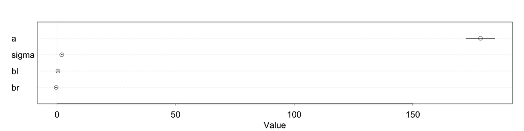

```r
precis(mod5, prob = 0.95) %>% plot(., cex = 2)
```

> Etrange mais… Le modèle ne fait que répondre à la question qu'on lui pose :  
> Une fois que je connais la taille de la jambe gauche, quelle est la valeur prédictive de la taille de la jambe droite (ou vice versa) ?

### Régression multiple

### LES RISQUES : La colinéarité

> Comment traquer la colinéarité de deux prédicteurs ?

En *plottant* la distribution postérieure de ces deux paramètres :

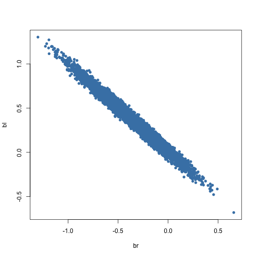

```r
post <- extract.samples(mod5)
plot(bl ~ br, post, pch = 16, col = "steelblue")
```

### Régression multiple

### LES RISQUES : La colinéarité

> Comment traquer la colinéarité de deux prédicteurs ?

En *plottant* la distribution postérieure de la somme des deux paramètres :

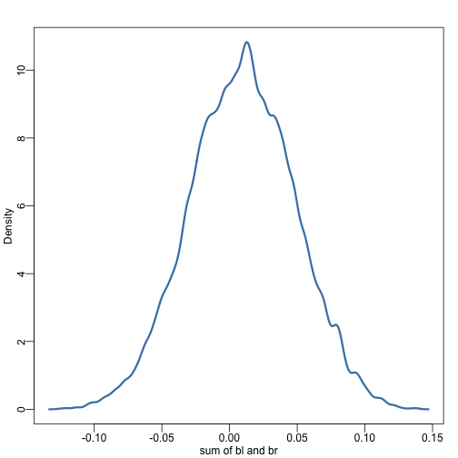

```r
sum_blbr <- post$bl + post$br
dens(sum_blbr, col = "steelblue", lwd = 3, xlab = "sum of bl and br", cex = 2)
```

```r
HPDI(sum_blbr, prob = 0.95)
```

```
      |0.95       0.95|
-0.06602761  0.08353036
```

### Régression multiple

### LES RISQUES : La colinéarité

Implémentation du modèle

```r
mod6 <- map(alist(
        height ~ dnorm(mu, sigma),
        mu <- a + bl * leg_left,
        a ~ dnorm(0, 100),
        bl ~ dnorm(0, 10),
        sigma ~ dunif(0, 10) ),
        data = df2,
        start = list(a = mean(df2$height), sigma = sd(df2$height) ) )
```

```r
precis(mod6, prob = 0.95)
```

```
        mean   sd   2.5%  97.5%
a     178.08 3.11 171.98 184.18
sigma   2.00 0.14   1.72   2.28
bl      0.01 0.04  -0.06   0.09
```

### Régression multiple

### LES RISQUES : dépendance entre les prédicteurs

Problèmes qui arrivent lorsqu'on inclue des prédicteurs qui sont eux-mêmes définis directement ou indirectement par d'autres prédicteurs eux-même inclus dans le modèle.

Supposons qu'on s'intéresse à la pousse des plantes en serre. On voudrait savoir quel traitement permettant de réduire la présence de champignons améliore la pousse des plantes.

On commence donc par planter et laisser germer des graines, mesurer la taille initiale des pousses, puis appliquer différents traitements.

Enfin, on mesure à la fin de l'expérience la taille finale de chaque plante et la présence de champignons.

### Régression multiple

### LES RISQUES : dépendance entre les prédicteurs

Création des données

```r
# number of plants
N <- 100
# simulate initial heights
h0 <- rnorm(N, mean = 10, sd = 2)
# assign treatments and simulate fungus and growth
treatment <- rep(0:1, each = N / 2)
fungus <- rbinom(N, size = 1, prob = 0.5 - treatment * 0.4)
h1 <- h0 + rnorm(N, mean = 5 - 3 * fungus)
# compose a clean data frame
df3 <- data.frame(h0, h1, treatment, fungus)

head(df3)
```

```
         h0       h1 treatment fungus
1  6.447515 11.64746         0      0
2  9.374036 12.25078         0      1
3  7.441160 13.52380         0      0
4 10.703124 12.53801         0      1
5 12.041168 17.41520         0      0
6 13.589396 19.54550         0      0
```

### Régression multiple

### LES RISQUES : dépendance entre les prédicteurs

Implémentation du modèle

```r
mod7 <- map(alist(
        h1 ~ dnorm(mu, sigma),
        mu <- a + bh*h0 + bt*treatment + bf*fungus,
        a ~ dnorm(0, 10),
        c(bh,bt,bf) ~ dnorm(0, 10),
        sigma ~ dunif(0, 10) ),
        data = df3)
```

### Régression multiple

### LES RISQUES : dépendance entre les prédicteurs

Estimation des paramètres

```r
precis(mod7, prob = 0.95)
```

```
       mean   sd  2.5% 97.5%
a      5.27 0.42  4.45  6.09
bh     0.98 0.04  0.90  1.07
bt    -0.22 0.20 -0.61  0.16
bf    -2.97 0.22 -3.39 -2.55
sigma  0.88 0.06  0.76  1.01
```

**On remarque que l'effet du traitement est négligeable…**

- la présence des champignons (`fungus`) est une conséquence de l'application du `treatment`.
- On demande au modèle si le traitement a une influence sachant que la plante a (ou n'a pas) développé des champignons.

Nous nous intéressons plutôt l'influence du traitement sur la pousse.  
\( \Longrightarrow~~ \) Il suffit de fitter un modèle sans la variable `fungus`.

### Régression multiple

### LES RISQUES : dépendance entre les prédicteurs

Implémentation du modèle sans le paramètre `fungus`.

```r
mod8 <- map(alist(
        h1 ~ dnorm(mu, sigma),
        mu <- a + bh*h0 + bt*treatment,
        a ~ dnorm(0, 100),
        c(bh,bt) ~ dnorm(0, 1),
        sigma ~ dunif(0, 10) ),
        data = df3)
```

```r
precis(mod8, prob = 0.95)
```

```
      mean   sd 2.5% 97.5%
a     4.51 0.71 3.13  5.90
bh    0.92 0.07 0.78  1.06
bt    0.81 0.29 0.24  1.38
sigma 1.51 0.11 1.30  1.71
```

**L'influence du traitement est maintenant forte, et positive.**  
Remarque : il fait sens de prendre en compte \( h0 \), la taille initiale, car les différences observées pourraient masquer l'effet du traitement.

### Planning

## Cours

Cours 1: Introduction à l'inférence bayésienne

Cours 2: Modèle beta-binomial

**Cours 3 & 4: Modèle de régression linéaire**

Cours 5: Markov Chain Monte Carlo

Cours 6: Modèle linéaire généralisé

Cours 7: Comparaison de modèles

Cours 8: Modèles multi-niveaux

Cours 9: Introduction à `brms`

Cours 10: Data Hackaton

## Plan

- Rappels et objectifs
- Régression linéaire : multiples facteurs continus
- **Régression linéaire : un facteur catégoriel**
- Régression linéaire : 2 facteurs catégoriels et interaction

### Prédicteurs catégoriels

### CATÉGORIES BINAIRES

Chargement des données

```r
data(Howell1)
df4 <- Howell1
str(df4)
```

```
'data.frame':   544 obs. of  4 variables:
 $ height: num  152 140 137 157 145 ...
 $ weight: num  47.8 36.5 31.9 53 41.3 ...
 $ age   : num  63 63 65 41 51 35 32 27 19 54 ...
 $ male  : int  1 0 0 1 0 1 0 1 0 1 ...
```

Le **genre** est codé comme une **dummy variable**, c'est à dire une suite de \( 0 \) et de \( 1 \).  
Il faut imaginer que cette nouvelle variable **active** le paramètre uniquement pour la catégorie codée \( 1 \), et le **désactive** pour la catégorie codée \( 0 \).

### Prédicteurs catégoriels

### CATÉGORIES BINAIRES

Le modèle théorique \[ \color{orangered}{h_{i} \sim \mathrm{Normal}(\mu_{i},\sigma)} \] \[ \mu_{i}= \alpha + \beta_{m}m_{i} \] \[ \color{steelblue}{\alpha \sim \mathrm{Normal}(178,100)} \] \[ \color{steelblue}{\beta_{m} \sim \mathrm{Normal}(0,10)} \] \[ \color{steelblue}{\sigma \sim \mathrm{Uniform}(0,50)} \]

Implémentation du modèle

```r
mod9 <- map(alist(
        height ~ dnorm(mu, sigma),
        mu <- a + bm * male,
        a ~ dnorm(178, 100),
        bm ~ dnorm(0, 10),
        sigma ~ dunif(0, 50) ),
        data = df4)
```

### Prédicteurs catégoriels

### CATÉGORIES BINAIRES

- \( \alpha \) est la taille moyenne des femmes (car \( \mu_{i} = \beta_{m}(0) = \alpha \)).

```r
precis(mod9, prob = 0.95)
```

```
        mean   sd   2.5%  97.5%
a     134.83 1.59 131.71 137.95
bm      7.28 2.28   2.80  11.75
sigma  27.31 0.83  25.69  28.93
```

- \( \beta \) nous indique la différence de taille en moyenne entre les hommes et les femmes.  
  Pour obtenir la taille moyenne des hommes, il suffit donc d'ajouter \( \alpha \) et \( \beta \).

```r
post <- extract.samples(mod9)
mu.male <- post$a + post$bm
HPDI(mu.male, prob = 0.95)
```

```
   |0.95    0.95|
138.8933 145.5195
```

### Prédicteurs catégoriels

### CATÉGORIES BINAIRES

Au lieu d'utiliser un paramètre pour la différence entre les deux catégories, on pourrait estimer un paramètre par catégorie…

\[ \begin{align} h_{i} &\sim \mathrm{Normal}(\mu_{i},\sigma) \\ \mu_{i}&= \alpha_{f}(1 - m_{i}) + \alpha_{h}m_{i} \\ \end{align} \]

Cette formulation semble strictement équivalente à la précedente comme :

\[ \begin{align} \mu_{i}&= \alpha_{f}(1 - m_{i}) + \alpha_{h}m_{i} \\ &= \alpha_{f} + (\alpha_{m} - \alpha_{f}) m_{i} \\ \end{align} \]

où \( (\alpha_{m} - \alpha_{f}) \) est égal à la différence entre la moyenne des hommes et la moyenne des femmes, i.e., \( \beta_{m} \).

> Attention : il y a plus d'incertitude pour les hommes (2 paramètres) que pour les femmes (1 paramètre) dans la formulation précédente que dans cette formulation où homme et femme ont 1 paramètre.

### Prédicteurs catégoriels

### CATÉGORIES BINAIRES

Implémentation du modèle

```r
mod10 <- map(alist(
        height ~ dnorm(mu, sigma),
        mu <- af * (1 - male) + ah * male,
        af ~ dnorm(178, 100),
        ah ~ dnorm(178 ,100),
        sigma ~ dunif(0, 50) ),
        data = df4,
        start = list(af = mean(df4$height), af = mean(df4$height), sigma = sd(df4$height)))
```

Estimation des paramètres

```r
precis(mod10, prob = 0.95)
```

```
        mean   sd   2.5%  97.5%
af    134.64 1.61 131.49 137.80
sigma  27.31 0.83  25.68  28.93
ah    142.33 1.70 139.00 145.67
```

### Prédicteurs catégoriels

### TAILLE D'EFFET

\[ \rho^{2} = \dfrac{\sum_{i=1}^{n} \pi_{i}(\beta_{i} - \beta)^{2}}{\sigma^{2} + \sum_{i=1}^{n} \pi_{i}(\beta_{i} - \beta)^{2}} \]

Implémentation du calcul

```r
post <- extract.samples(mod9)
pi <- sum(df4$male) / length(df4$male) # prop of male

beta <- post$bm # posterior samples for beta
sigma <- post$sigma # posterior samples for sigma

f1 <- pi * (beta - beta * pi)^2
rho <- f1 / (f1 + sigma^2)
```

### Prédicteurs catégoriels

### TAILLE D'EFFET

\[ \rho^{2} = \dfrac{\sum_{i=1}^{n} \pi_{i}(\beta_{i} - \beta)^{2}}{\sigma^{2} + \sum_{i=1}^{n} \pi_{i}(\beta_{i} - \beta)^{2}} \]

Affichage du résultat

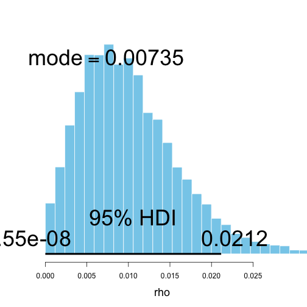

```r
BEST::plotPost(rho, showMode = TRUE, cex = 3) # krushke's plot
```

### Prédicteurs catégoriels

### D DE COHEN BAYÉSIEN

\[ \text{Cohen's d} = \frac{\text{différence des moyennes}}{\text{écart-type}} \]

Affichage du résultat

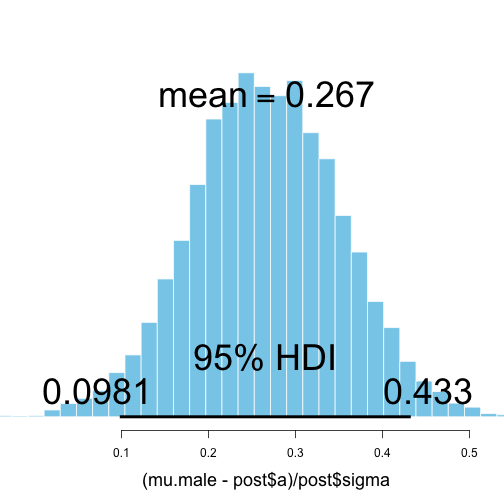

```r
BEST::plotPost((mu.male - post$a) / post$sigma, cex = 3)
```

### Prédicteurs catégoriels

### CATÉGORIES \( \geq \) 3

Chargement des données

```r
data(milk)
df5 <- milk
str(df5)
```

```
'data.frame':   29 obs. of  8 variables:
 $ clade         : Factor w/ 4 levels "Ape","New World Monkey",..: 4 4 4 4 4 2 2 2 2 2 ...
 $ species       : Factor w/ 29 levels "A palliata","Alouatta seniculus",..: 11 8 9 10 16 2 1 6 28 27 ...
 $ kcal.per.g    : num  0.49 0.51 0.46 0.48 0.6 0.47 0.56 0.89 0.91 0.92 ...
 $ perc.fat      : num  16.6 19.3 14.1 14.9 27.3 ...
 $ perc.protein  : num  15.4 16.9 16.9 13.2 19.5 ...
 $ perc.lactose  : num  68 63.8 69 71.9 53.2 ...
 $ mass          : num  1.95 2.09 2.51 1.62 2.19 5.25 5.37 2.51 0.71 0.68 ...
 $ neocortex.perc: num  55.2 NA NA NA NA ...
```

Règle : pour \( k \) catégories, nous aurons besoin de \( k - 1 \) *dummy variables*.

```r
df5$clade.NWM <- ifelse( df5$clade=="New World Monkey", 1, 0)
df5$clade.OWM <- ifelse( df5$clade=="Old World Monkey", 1, 0)
df5$clade.S <- ifelse( df5$clade=="Strepsirrhine", 1, 0)
```

Pas la peine de créer une variable pour `ape`, qui sera notre *intercept*.

### Prédicteurs catégoriels

### CATÉGORIES \( \geq \) 3

Le modèle théorique \[ \color{orangered}{k_{i} \sim \mathrm{Normal}(\mu_{i},\sigma)} \\ \mu_{i} = \alpha + \beta_{NWM}NWM_{i} + \beta_{OWM}OWM_{i} + \beta_{S}S_{i} \\ \color{steelblue}{\alpha \sim \mathrm{Normal}(0.6,10)} \\ \color{steelblue}{\beta_{NWM} \sim \mathrm{Normal}(0,1)} \\ \color{steelblue}{\beta_{OWM} \sim \mathrm{Normal}(0,1)} \\ \color{steelblue}{\beta_{S} \sim \mathrm{Normal}(0,1)} \\ \color{steelblue}{\sigma \sim \mathrm{Uniform}(0,10)} \]

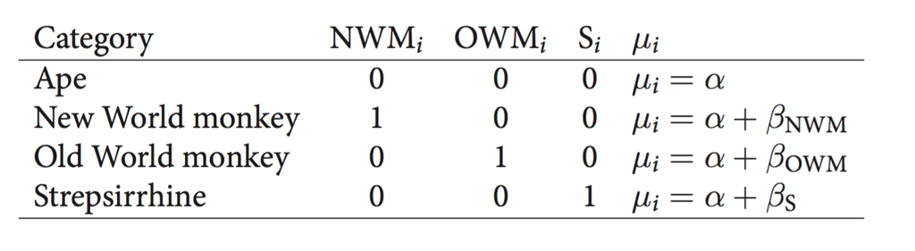

### Prédicteurs catégoriels

### CATÉGORIES \( \geq \) 3

Implémentation du modèle

```r
mod11 <- map(alist(
        kcal.per.g ~ dnorm(mu, sigma),
        mu <- a + b.NWM * clade.NWM + b.OWM * clade.OWM + b.S * clade.S,
        a ~ dnorm(0.6, 10),
        b.NWM ~ dnorm(0, 1),
        b.OWM ~ dnorm(0, 1),
        b.S ~ dnorm(0, 1),
        sigma ~ dunif(0, 10) ),
        data = df5)
```

Estimation des paramètres

```r
precis(mod11, prob = 0.95)
```

```
       mean   sd  2.5% 97.5%
a      0.55 0.04  0.47  0.62
b.NWM  0.17 0.05  0.06  0.27
b.OWM  0.24 0.06  0.12  0.36
b.S   -0.04 0.06 -0.16  0.09
sigma  0.11 0.02  0.09  0.14
```

### Prédicteurs catégoriels

### CATÉGORIES \( \geq \) 3

Présentation des résultats

```r
# sample posterior
post <- extract.samples(mod11)

# compute averages for each category
mu.ape <- post$a
mu.NWM <- post$a + post$b.NWM
mu.OWM <- post$a + post$b.OWM
mu.S <- post$a + post$b.S
```

```r
precis(data.frame(mu.ape,mu.NWM,mu.OWM,mu.S), prob = 0.95)
```

```
'data.frame': 10000 obs. of 4 variables:
       mean   sd 2.5% 97.5%       histogram
mu.ape 0.55 0.04 0.47  0.62         ▁▁▂▇▇▁▁
mu.NWM 0.71 0.04 0.64  0.79 ▁▁▁▁▂▃▅▇▇▅▂▁▁▁▁
mu.OWM 0.79 0.05 0.70  0.88        ▁▁▃▇▇▂▁▁
mu.S   0.51 0.05 0.41  0.61        ▁▁▂▇▇▃▁▁
```

### Prédicteurs catégoriels

### CATÉGORIES \( \geq \) 3

Si on s'intéresse à la différence entre deux groupes de singes, il suffit de soustraire les moyennes estimées.

```r
diff.NWM.OWM <- mu.NWM - mu.OWM
quantile(diff.NWM.OWM, probs = c(0.025, 0.5, 0.975) )
```

```
       2.5%         50%       97.5%
-0.18910528 -0.07364626  0.04256977
```

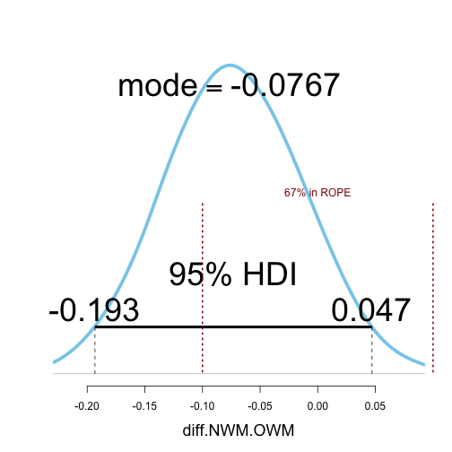

```r
BEST::plotPost(diff.NWM.OWM, ROPE=c(-0.1,0.1), showMode=TRUE, showCurve=TRUE, cex = 3)
```

### Prédicteurs catégoriels

### CATÉGORIES \( \geq \) 3 - deuxième approche

Une autre manière de considérer les variables catégorielles consiste à construire un vecteur d'intercepts, un pour chaque catégorie. On va créer un *index* dans le jeu de données qui indique quel paramètre doit aller avec quelle catégorie.

```r
(df5$clade_id <- coerce_index(df5$clade) )
```

```
 [1] 4 4 4 4 4 2 2 2 2 2 2 2 2 2 3 3 3 3 3 3 1 1 1 1 1 1 1 1 1
```

\[ \color{orangered}{k_{i} \sim \mathrm{Normal}(\mu_{i},\sigma)} \\ \mu_{i} = \alpha_{\text{clade}[i]} \\ \color{steelblue}{\alpha_{\text{clade}[i]} \sim \mathrm{Normal}(0.6,10)} \\ \color{steelblue}{\sigma \sim \mathrm{Uniform}(0,10)} \]

### Prédicteurs catégoriels

### CATÉGORIES \( \geq \) 3 - deuxième approche

Implémentation du modèle

```r
mod12 <- map(alist(
        kcal.per.g ~ dnorm(mu, sigma),
        mu <- a[clade_id],
        a[clade_id] ~ dnorm(0.6, 10),
        sigma ~ dunif(0, 10) ),
        data = df5)
```

Estimation des paramètres

```r
precis(mod12, prob = 0.95, depth = 2)
```

```
      mean   sd 2.5% 97.5%
a[1]  0.55 0.04 0.47  0.62
a[2]  0.71 0.04 0.64  0.79
a[3]  0.79 0.05 0.70  0.88
a[4]  0.51 0.05 0.41  0.61
sigma 0.11 0.02 0.09  0.14
```

### Planning

## Cours

Cours 1: Introduction à l'inférence bayésienne

Cours 2: Modèle beta-binomial

**Cours 3 & 4: Modèle de régression linéaire**

Cours 5: Markov Chain Monte Carlo

Cours 6: Modèle linéaire généralisé

Cours 7: Comparaison de modèles

Cours 8: Modèles multi-niveaux

Cours 9: Introduction à `brms`

Cours 10: Data Hackaton

## Plan

- Rappels et objectifs
- Régression linéaire : multiples facteurs continus
- Régression linéaire : un facteur catégoriel
- **Régression linéaire : 2 facteurs catégoriels et interaction**

### Interaction

Jusque là, chacun des prédicteurs du modèle entretenait des relations mutuellement indépendantes avec la variable mesurée. Et si nous souhaitions que ces relations soient **conditionnelles**, ou **dépendantes** les unes des autres ?

Exemple: on s'intéresse à la pousse des tulipes selon la quantité de lumière reçue et l'humidité du sol. Il se pourrait que la relation entre quantité de lumière reçue et pousse des tulipes soit différente selon l'humidité du sol, i.e., soit **conditionnelle** à l'humidité du sol…

### Interaction

### LES DONNÉES

Chargement des données

```r
data(tulips)
df6 <- tulips
head(df6,15)
```

```
   bed water shade blooms
1    a     1     1   0.00
2    a     1     2   0.00
3    a     1     3 111.04
4    a     2     1 183.47
5    a     2     2  59.16
6    a     2     3  76.75
7    a     3     1 224.97
8    a     3     2  83.77
9    a     3     3 134.95
10   b     1     1  80.10
11   b     1     2  85.95
12   b     1     3  19.87
13   b     2     1 213.13
14   b     2     2 124.99
15   b     2     3  65.48
```

### Interaction

### MODÈLES THÉORIQUES (likelihood)

Modèle sans interaction

\[ \begin{align} B_{i} &\sim \mathrm{Normal}(\mu, \sigma) \\ \mu_{i} &= \alpha + \beta_{W} W_{i} + \beta_{S} S_{i} \\ \end{align} \]

Modèle avec interaction

\[ \begin{align} B_{i} &\sim \mathrm{Normal}(\mu, \sigma) \\ \mu_{i} &= \alpha + \beta_{W} W_{i} + \beta_{S} S_{i} + \beta_{WS} W_{i} S_{i}\\ \end{align} \]

Centrage des données (pour l'interprétation)

```r
df6$shade.c <- df6$shade - mean(df6$shade)
df6$water.c <- df6$water - mean(df6$water)
```

### Interaction

### IMPLÉMENTATION

Modèle sans interaction

```r
mod13.1 <- map(alist(
        blooms ~ dnorm(mu, sigma),
        mu <- a + bW*water.c + bS*shade.c,
        a ~ dnorm(130, 100),
        bW ~ dnorm(0, 100),
        bS ~ dnorm(0, 100),
        sigma ~ dunif(0, 100) ),
        data = df6,
        method = "Nelder-Mead",
        control = list(maxit = 1e4) )
```

Modèle avec interaction

```r
mod13.2 <- map(alist(
        blooms ~ dnorm(mu, sigma),
        mu <- a + bW*water.c + bS*shade.c + bWS*water.c*shade.c,
        a ~ dnorm(130, 100),
        bW ~ dnorm(0, 100),
        bS ~ dnorm(0, 100),
        bWS ~ dnorm(0, 100),
        sigma ~ dunif(0, 100) ),
        data = df6,
        method = "Nelder-Mead",
        control = list(maxit = 1e4) )
```

### Interaction

### COMPARAISON DES DEUX MODÈLES

```r
coeftab(mod13.1, mod13.2)
```

```
      mod13.1 mod13.2
a      129.00  129.06
bW      74.44   74.94
bS     -40.80  -41.17
sigma   57.36   45.26
bWS        NA  -51.87
nobs       27      27
```

### Interaction

### PLOT

Dans un modèle qui inclue un effet d'interaction, l'effet d'un prédicteur sur la mesure va dépendre de la valeur de l'autre prédicteur. La meilleure manière de représenter cette dépendance est plotter la relation entre un prédicteur et la mesure, à différentes valeurs de l'autre prédicteur…

```r
par(mfrow = c(1, 3) ) # three-columns plots

for (w in -1:1){
    dt <- d[d$water.c==w,]
    plot(blooms ~ shade.c, data = dt, col = "steelblue",
        main = paste("water.c =", w), xaxp = c(-1,1,2), ylim = c(0,362),
        xlab = "shade (centered)")

    mu <- link(mod13.2,
            data = data.frame(water.c = w, shade.c = -1:1),
            refresh = 0)
    mu.mean <- apply(mu, 2, mean)
    mu.HPDI <- apply(mu, 2, HPDI, prob = 0.95)

    lines(-1:1, mu.mean)
    lines(-1:1, mu.HPDI[1,], lty = 2)
    lines(-1:1, mu.HPDI[2,], lty = 2)
}
```

### Interaction

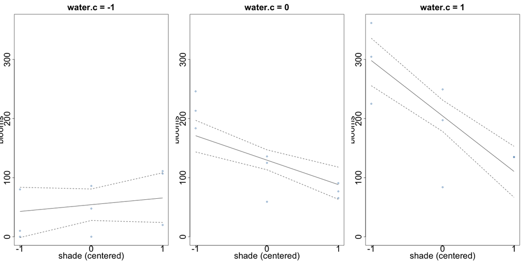

### Interaction

### EN RÉSUMÉ

L'effet d'interaction nous indique que les tulipes ont besoin à la fois d'eau et de lumière pour pousser, mais aussi qu'à de faibles niveaux d'humidité, la luminosité a peu d'effet, tandis que cet effet est plus important à haut niveau d'humidité.

Cette explication vaut de manière **symétrique** pour l'effet de l'humidité sur la relation entre la luminosité et la pousse des plantes.

### FIN

### Exercice

Cet exemple est basé sur le jeu de données `mtcars`, issu du volume de 1974 de *Motor Trend US*. La mesure est la consommation de carburant, en *miles per gallon* (mpg).

```r
data(mtcars)
head(mtcars)
```

```
                   mpg cyl disp  hp drat    wt  qsec vs am gear carb
Mazda RX4         21.0   6  160 110 3.90 2.620 16.46  0  1    4    4
Mazda RX4 Wag     21.0   6  160 110 3.90 2.875 17.02  0  1    4    4
Datsun 710        22.8   4  108  93 3.85 2.320 18.61  1  1    4    1
Hornet 4 Drive    21.4   6  258 110 3.08 3.215 19.44  1  0    3    1
Hornet Sportabout 18.7   8  360 175 3.15 3.440 17.02  0  0    3    2
Valiant           18.1   6  225 105 2.76 3.460 20.22  1  0    3    1
```

### Exercice

Imaginons que nous souhaitions savoir comment la cylindrée affecte la relation entre le nombre de cylindres et la consommation de carburant et / ou comment le nombre de cylindres affecte la relation entre la cylindrée et la consommation de carburant. Ce genre d'effet appelle une analyse d'interaction…

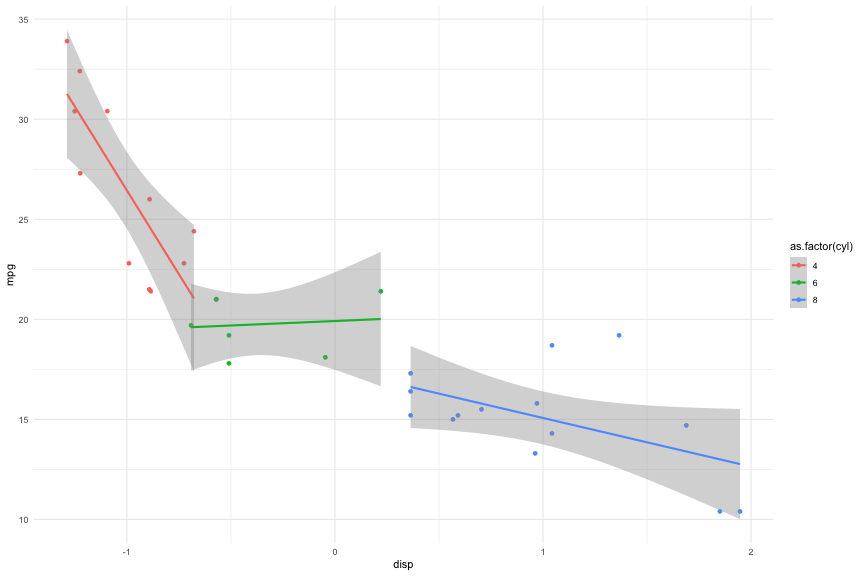

### Exercice

```r
m_cyl <- lm(mpg ~ disp * cyl, data = mtcars)
summary(m_cyl)
```

```
Call:
lm(formula = mpg ~ disp * cyl, data = mtcars)

Residuals:
    Min      1Q  Median      3Q     Max
-4.0809 -1.6054 -0.2948  1.0546  5.7981

Coefficients:
            Estimate Std. Error t value Pr(>|t|)
(Intercept)  15.4612     5.9382   2.604  0.01459 *
disp        -18.0363     4.9579  -3.638  0.00110 **
cyl           0.2526     0.8448   0.299  0.76716
disp:cyl      1.9649     0.6132   3.204  0.00337 **
---
Signif. codes:  0 '***' 0.001 '**' 0.01 '*' 0.05 '.' 0.1 ' ' 1

Residual standard error: 2.66 on 28 degrees of freedom
Multiple R-squared:  0.8241,    Adjusted R-squared:  0.8052
F-statistic: 43.72 on 3 and 28 DF,  p-value: 1.078e-10
```

### Solution (proposition)

Implémentation du modèle

```r
mod14 <- map(alist(
        mpg ~ dnorm(mu, sigma),
        mu <- a + bd*disp + bc*cyl + bd_bc*disp*cyl,
        a ~ dnorm(20, 100),
        c(bd,bc,bd_bc) ~ dnorm(0, 100),
        sigma ~ dunif(0, 50) ),
        data = mtcars)
```

Estimation des paramètres

```r
precis(mod14, prob = 0.95)
```

```
        mean   sd   2.5% 97.5%
a      15.52 5.54   4.66 26.38
bd    -17.99 4.63 -27.05 -8.92
bc      0.25 0.79  -1.30  1.79
bd_bc   1.96 0.57   0.84  3.08
sigma   2.49 0.31   1.88  3.10
```

### glimmer

Le package `rethinking` contient une fonction utile qui *traduit* les modèles de la syntaxe `lm` vers la syntaxe `map`.

```r
glimmer(mpg ~ cyl * disp, data = mtcars)
```

```
alist(
    mpg ~ dnorm( mu , sigma ),
    mu <- Intercept +
        b_cyl*cyl +
        b_disp*disp +
        b_cyl_X_disp*cyl_X_disp,
    Intercept ~ dnorm(0,10),
    b_cyl ~ dnorm(0,10),
    b_disp ~ dnorm(0,10),
    b_cyl_X_disp ~ dnorm(0,10),
    sigma ~ dcauchy(0,2)
)
```